# New service year data analysis

ZahraAfaghi

2024-12-01

**part1 Data recall** #پس از آنکه داده‌های salaries از بسته car یک نمونه تصادفی از مشاغل را انتخاب کرد و سال های خدمت آن ها را در متغیر yrs_service ذخیره کرده سپس با توجه به مقدار ذخیره شده در my.id تعداد سطرهای که به طور تصادفی انتخاب میشود را میشخص میکنند.

```r
my.id <- 20 + 63
set.seed(my.id)
library(car)
data(Salaries)
sample_data <- Salaries[sample(nrow(Salaries), my.id), ]
yrs_service <- sample_data$yrs.service
```

# این کد به محاسبه و نمایش آمارهای توصیفی سال های خدمت yrs.service از دادههای sample_data می‌ردازیم که شامل میانگین، میانه، انحراف معیار، واریانس، دامنه و چارکهااست و درآخر نتایج به صورت متنی چاپ میشوند.

```r
yrs_service <- sample_data$yrs.service

mean_yrs_service <- mean(yrs_service, na.rm = TRUE)
median_yrs_service <- median(yrs_service, na.rm = TRUE)
sd_yrs_service <- sd(yrs_service, na.rm = TRUE)
var_yrs_service <- var(yrs_service, na.rm = TRUE)
range_yrs_service <- range(yrs_service, na.rm = TRUE)
quartiles <- quantile(yrs_service, na.rm = TRUE)

print(paste("Mean:", mean_yrs_service))
```

```
## [1] "Mean: 16.3373493975904"
```

```r
print(paste("Median:", median_yrs_service))
```

```
## [1] "Median: 14"
```

```r
print(paste("Standard Deviation:", sd_yrs_service))
```

```
## [1] "Standard Deviation: 12.719561570556"
```

```r
print(paste("Variance:", var_yrs_service))
```

```
## [1] "Variance: 161.787246547164"
```

```r
print(paste("Range:", range_yrs_service[1], "to", range_yrs_service[2]))
```

```
## [1] "Range: 0 to 49"
```

```r
print(paste("Quartiles:", quartiles))
```

```
## [1] "Quartiles: 0"  "Quartiles: 6"  "Quartiles: 14" "Quartiles: 23"
## [5] "Quartiles: 49"
```

#در اینجا با استفاده از کتابخانه e1071 چولگی (skewness) و کشیدگی (kurtosis) سالهای خدمت yrs.service را محاسبه می‌کنیم و سپس مقادیر حاصل را چاپ کرده

```r
library(e1071)
skewness_val <- skewness(yrs_service)
kurtosis_val <- kurtosis(yrs_service)
print(paste("Skewness:", skewness_val))
```

```
## [1] "Skewness: 0.76865579871953"
```

```r
print(paste("Kurtosis:", kurtosis_val))
```

```
## [1] "Kurtosis: -0.25923239715185"
```

#در اینجا دادهها را به صورت نمودار هیستوگرام رسم میکنیم محور افقی تعداد سالهای خدمت را نشان میدهد

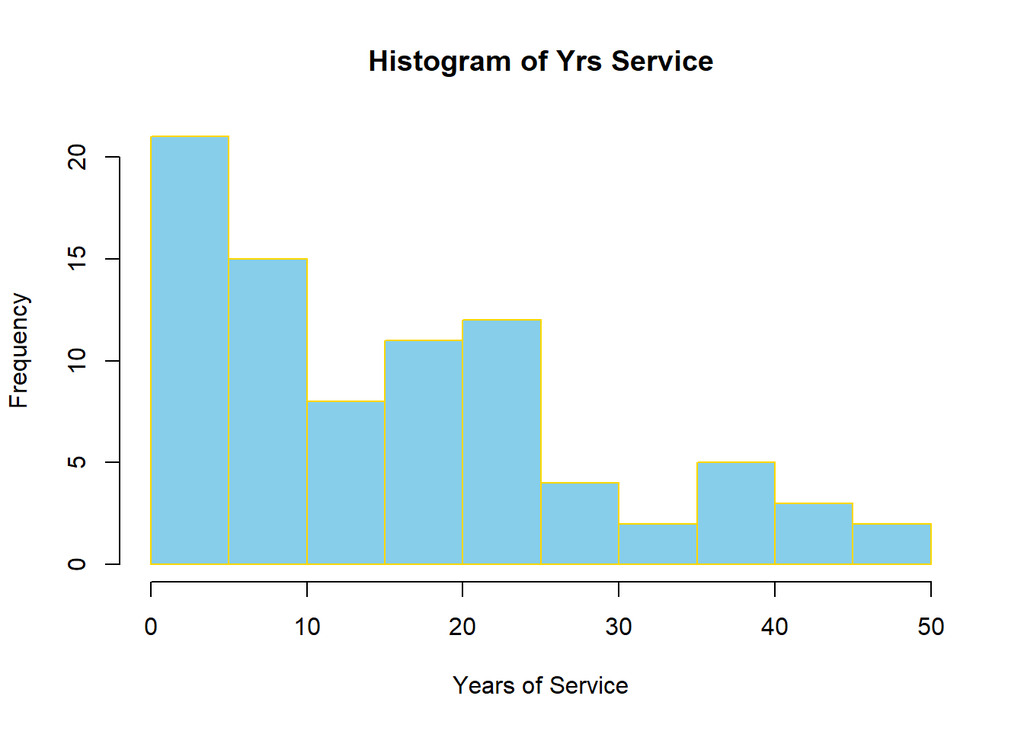

```r
hist(yrs_service, main="Histogram of Yrs Service", xlab="Years of Service", col = "skyblue",border = "gold")
```

**part2 Draw a box plot for salary data** #این کد با استفاده از مجموعه دادههای Salaries یک نمونه تصادفی از دادهها به اندازه my.id بر اساس ردیفها انتخاب میکند و سپس یک باکس پلات از حقوق ها بر اساس رتبه ها rank ایجاد می کند. باکس پلات نمایش دهندهی توزیع حقوقها و وجود ناهنجاریها در هر رتبه است.

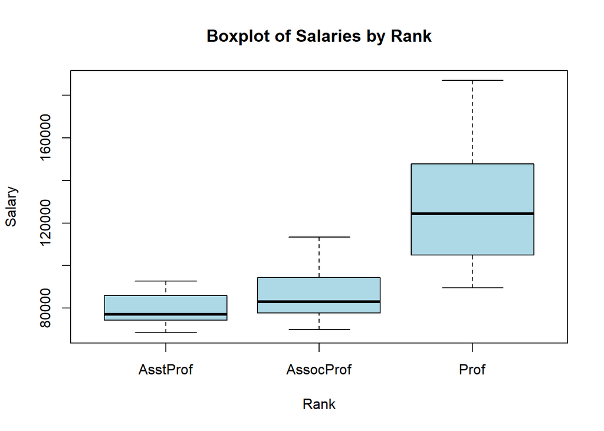

```r
my.id <- (63) + 20
library(car)
data("Salaries")
set.seed(my.id)
sample_size <- my.id
salaries_sample <- Salaries[sample(1:nrow(Salaries), sample_size), ]
boxplot(salary ~ rank, data = salaries_sample,
        main = "Boxplot of Salaries by Rank",
        xlab = "Rank", ylab = "Salary", col = "lightblue")
```

#نقاط ممکن است در یک الگوی خاص پراکنده شوند، اگر با افزایش سال های خدمت، حقوق هم افزایش یابد، نمودار هم‌راستای صعودی خواهد بود

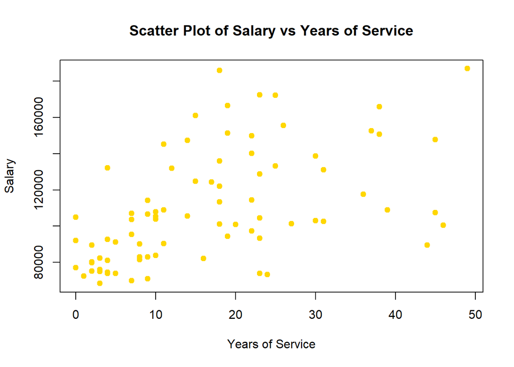

```r
plot(salary ~ yrs.service, data = salaries_sample,
     main = "Scatter Plot of Salary vs Years of Service",
     xlab = "Years of Service", ylab = "Salary", pch = 19, col = "gold")
```

**part3 Find multiples of 6** #یک سری عدد تصادفی تولید میکند و سپس اعداد را گرد میکند و فقط مضربهای ۶ را انتخاب میکند نکته مهم این است که با استفاده از set.seed(my.id) تولید اعداد تصادفی قابل تکرار میشود، بنابراین هر بار که این کد را اجرا کنید، همان اعداد تولید خواهد شد.

```r
my.id <- 63 + 20
set.seed(my.id)
numbers <- rnorm(100, mean=50, sd=10)
rounded_numbers <- round(numbers)
multiples_of_6 <- rounded_numbers[rounded_numbers %% 6 == 0]
print(multiples_of_6)
```

```
##  [1] 60 36 60 42 54 60 60 54 54 48 48 48 48 42 54 54
```

**part4** #کد زیر یک تابع به نام f تعداد عناصر یک وکتور را بر مجموع آن عناصر sum(x) تقسیم میکند و نتیجه را بازمیگرداند. سپس این تابع بر روی متغیر salary از دیتافریم Salaries اعمال میشود.

```r
my.id <- 20 + 63
set.seed(my.id)
library(dplyr)
f <- function(x) {
  n <- length(x)
  result <- n / sum(x)
  return(result)
}

output <- f(Salaries$salary)


print(output)
```

```
## [1] 8.794575e-06
```

**part5** #برای محاسبه انتگرال با دقت بالا و دیگر محاسبات از integrate از پکیج pracma استفاده میکنیم

```r
library(pracma)
integrand1 <- function(x) {
  return(1 + x^2)
}


result1 <- integrate(integrand1, 1, 3)
cat("The result of the first integral: ", result1$value, "\n")
```

```
## The result of the first integral:  10.66667
```

```r
integrand2 <- function(x, y) {
  return(x + y^2 - 1)
}
result2 <- 0
for (y in seq(0, 1, by = 0.01)) {
  inner_integral <- integrate(function(x) integrand2(x, y), 3, 5)
  result2 <- result2 + inner_integral$value * 0.01
}

cat("The result of the second integral: ", result2, "\n")
```

```
## The result of the second integral:  6.7367
```

**part6** #کد فوق یک ماتریس ۳x۳ به نام A ایجاد می کند و سپس دترمینان آن را محاسبه و چاپ می کند، همچنین معکوس ماتریس A را محاسبه کرده و نمایش میدهد. پس از آن، مقادیر قطر اصلی ماتریس با وکتور صفر (۰، ۰، ۰) جایگزین می شود و ماتریس ویرایش شده نمایش داده میشود.

```r
A <- matrix(c(1, 6, 9, 2, 1, 5, 4, 3, 3), nrow = 3, byrow = TRUE)

det_A <- det(A)
cat("Determinants of the matrix A:", det_A, "\n")
```

```
## Determinants of the matrix A: 90
```

```r
inv_A <- solve(A)
cat("Matrix inverse A:\n")
```

```
## Matrix inverse A:
```

```r
print(inv_A)
```

```
##             [,1]       [,2]       [,3]
## [1,] -0.13333333  0.1000000  0.2333333
## [2,]  0.15555556 -0.3666667  0.1444444
## [3,]  0.02222222  0.2333333 -0.1222222
```

```r
zero_vector <- c(0, 0, 0)
diag(A) <- zero_vector
cat("Matrix A after replacing the values on the main diameter with (0, 0, 0):\n")
```

```
## Matrix A after replacing the values on the main diameter with (0, 0, 0):
```

```r
print(A)
```

```
##      [,1] [,2] [,3]
## [1,]    0    6    9
## [2,]    2    0    5
## [3,]    4    3    0
```